# Exploratory Data Analysis-Project2

Lila Tsopelakou

Have total emissions from PM2.5 decreased in the United States from 1999 to 2008? Using the base plotting system, make a plot showing the total PM2.5 emission from all sources for each of the years 1999, 2002, 2005, and 2008. Upload a PNG file containing your plot addressing this question

```r
setwd("C:/Users/tsope/OneDrive/Υπολογιστής")
if(!file.exists("./dataStore")){dir.create("./dataStore")}
get.data.project <- "https://d396qusza40orc.cloudfront.net/exdata%2Fdata%2FNEI_data.zip"
download.file(get.data.project,destfile="./dataStore/exdata-data-NEI_data.zip",method="auto")
check.url <- file(get.data.project,"r")
if (!isOpen(check.url)) {
stop(paste("There's a problem with the data:",geterrmessage()))
}
zipfile.data = "exdata-data-NEI_data.zip"
if(!file.exists(zipfile.data)) {
unzip(zipfile="./dataStore/exdata-data-NEI_data.zip",exdir="./dataStore")
}
path_rf <- file.path("./dataStore" , "exdata-data-NEI_data")
files<-list.files(path_rf, recursive=TRUE)
files
```

```
## character(0)
```

```r
NEI <- readRDS("summarySCC_PM25.rds")
SCC <- readRDS("Source_Classification_Code.rds")
number.add.width<-800
number.add.height<-800
require(dplyr)
```

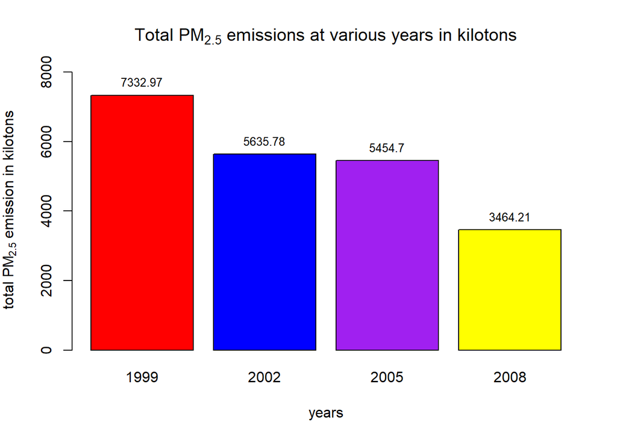

```r
 total.emissions <- summarise(group_by(NEI, year), Emissions=sum(Emissions))
 clrs <- c("red", "blue", "purple", "yellow")
 x1<-barplot(height=total.emissions$Emissions/1000, names.arg=total.emissions$year,xlab="years", ylab=expression('total PM'[2.5]*' emission in kilotons'),ylim=c(0,8000), main=expression('Total PM'[2.5]*' emissions at various years in kilotons'),col=clrs)
text(x = x1, y = round(total.emissions$Emissions/1000,2), label = round(total.emissions$Emissions/1000,2), pos = 3, cex = 0.8, col = "black")
```

Have total emissions from PM2.5 decreased in the Baltimore City, Maryland ( fips==24510) from 1999 to 2008? Use the base plotting system to make a plot answering this question.

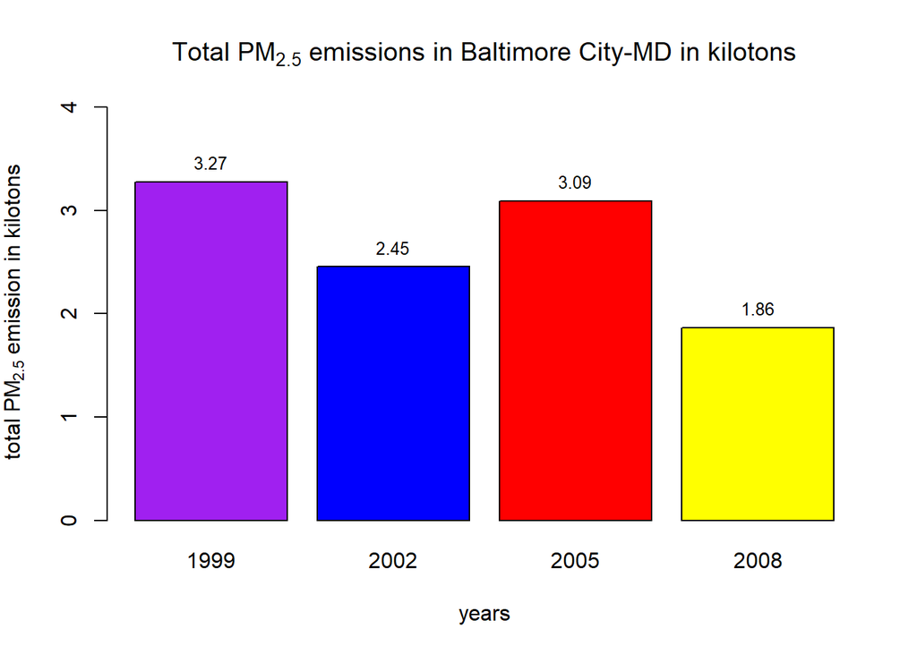

```r
baltcitymary.emissions<-summarise(group_by(filter(NEI, fips == "24510"), year), Emissions=sum(Emissions))
clrs <- c("purple", "blue", "red", "yellow")
x2<-barplot(height=baltcitymary.emissions$Emissions/1000, names.arg=baltcitymary.emissions$year,
xlab="years", ylab=expression('total PM'[2.5]*' emission in kilotons'),ylim=c(0,4),
main=expression('Total PM'[2.5]*' emissions in Baltimore City-MD in kilotons'),col=clrs)

## Add text at top of bars
text(x = x2, y = round(baltcitymary.emissions$Emissions/1000,2), label = round(baltcitymary.emissions$Emissions/1000,2), pos = 3, cex = 0.8, col = "black")
```

Of the four types of sources indicated by the type (point, nonpoint, onroad, nonroad) variable, which of these four sources have seen decreases in emissions from 1999–2008 for Baltimore City? Which have seen increases in emissions from 1999–2008? Use the ggplot2 plotting system to make a plot answer this question.

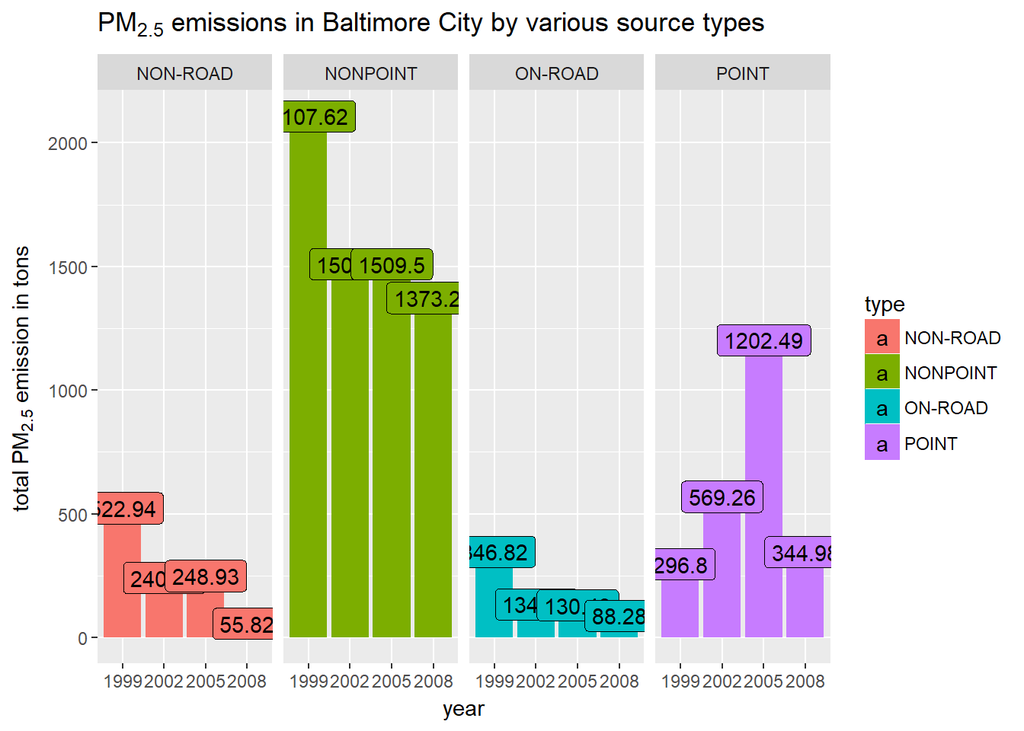

```r
require(ggplot2)
baltcitymary.emissions.byyear<-summarise(group_by(filter(NEI, fips == "24510"), year,type), Emissions=sum(Emissions))
ggplot(baltcitymary.emissions.byyear, aes(x=factor(year), y=Emissions, fill=type,label = round(Emissions,2))) +
geom_bar(stat="identity") +
facet_grid(. ~ type) +
xlab("year") +
ylab(expression("total PM"[2.5]*" emission in tons")) +
ggtitle(expression("PM"[2.5]*paste(" emissions in Baltimore ",
"City by various source types", sep="")))+
geom_label(aes(fill = type), colour = "black")
```

Across the United States, how have emissions from coal combustion-related sources changed from 1999–2008?

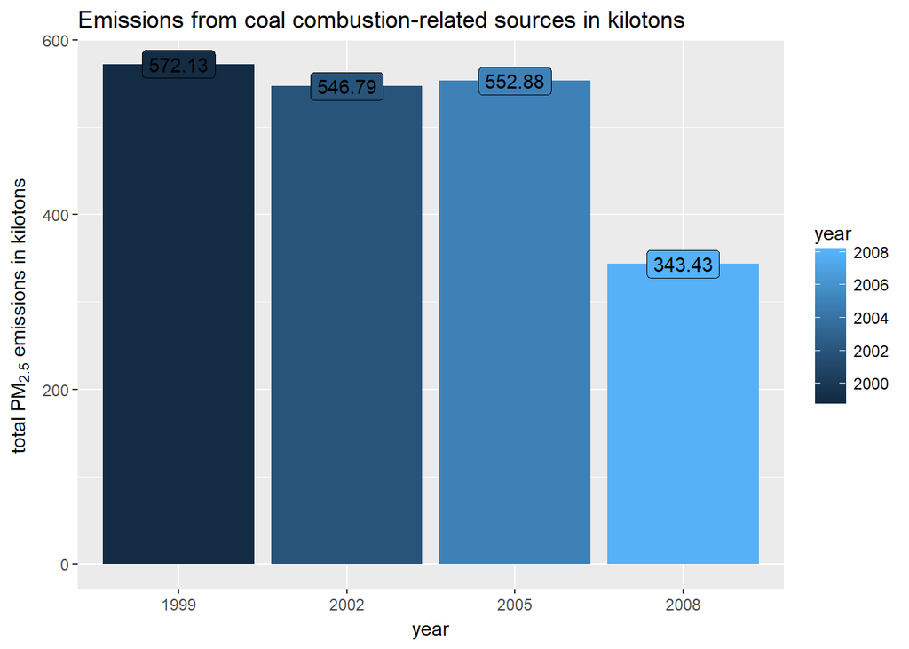

```r
combustion.coal <- grepl("Fuel Comb.*Coal", SCC$EI.Sector)
combustion.coal.sources <- SCC[combustion.coal,]
emissions.coal.combustion <- NEI[(NEI$SCC %in% combustion.coal.sources$SCC), ]
require(dplyr)
emissions.coal.related <- summarise(group_by(emissions.coal.combustion, year), Emissions=sum(Emissions))
require(ggplot2)
ggplot(emissions.coal.related, aes(x=factor(year), y=Emissions/1000,fill=year, label = round(Emissions/1000,2))) +
geom_bar(stat="identity") +
xlab("year") +
ylab(expression("total PM"[2.5]*" emissions in kilotons")) +
ggtitle("Emissions from coal combustion-related sources in kilotons")+
geom_label(aes(fill = year),colour = "black")
```

How have emissions from motor vehicle sources changed from 1999–2008 in Baltimore City?

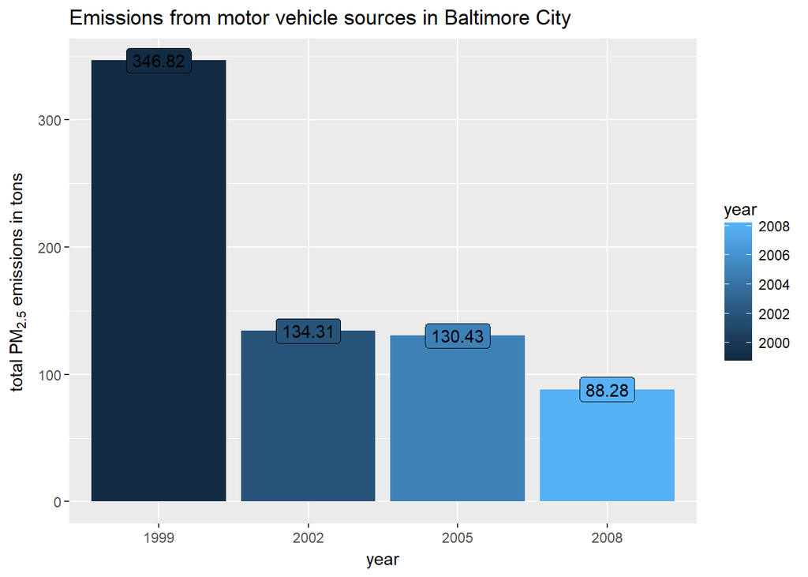

```r
baltcitymary.emissions<-NEI[(NEI$fips=="24510") & (NEI$type=="ON-ROAD"),]
require(dplyr)
baltcitymary.emissions.byyear <- summarise(group_by(baltcitymary.emissions, year), Emissions=sum(Emissions))
require(ggplot2)
ggplot(baltcitymary.emissions.byyear, aes(x=factor(year), y=Emissions,fill=year, label = round(Emissions,2))) +
geom_bar(stat="identity") +
xlab("year") +
ylab(expression("total PM"[2.5]*" emissions in tons")) +
ggtitle("Emissions from motor vehicle sources in Baltimore City")+
geom_label(aes(fill = year),colour = "black")
```

Compare emissions from motor vehicle sources in Baltimore City with emissions from motor vehicle sources in Los Angeles County, California (fips==06037). Which city has seen greater changes over time in motor vehicle emissions?

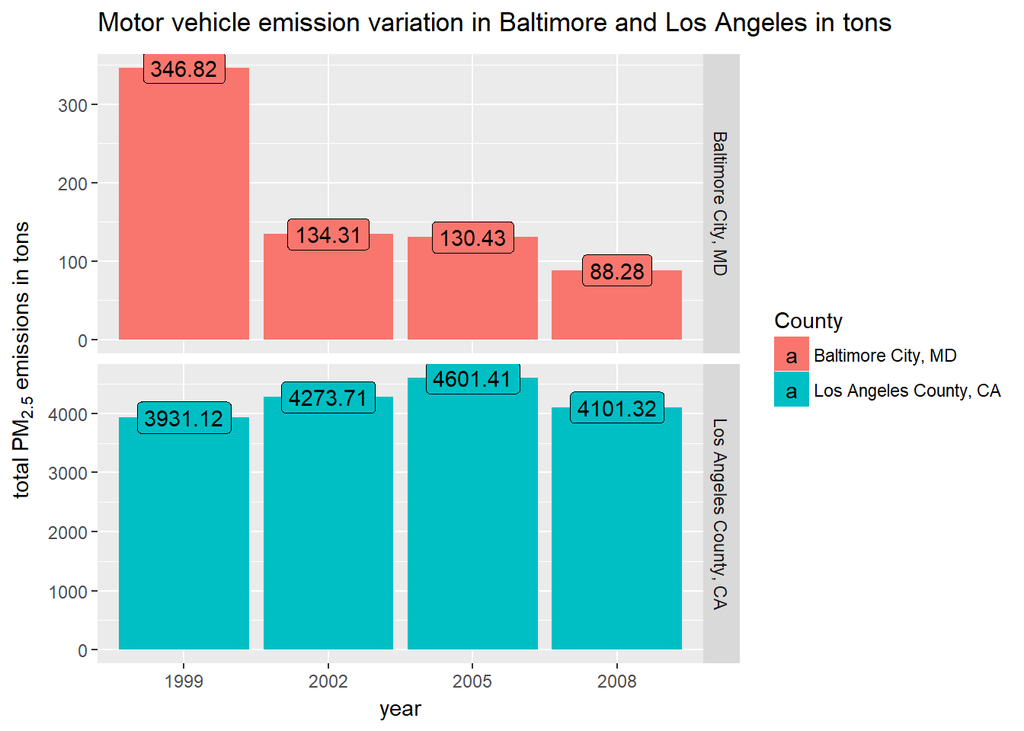

```r
require(dplyr)
baltcitymary.emissions<-summarise(group_by(filter(NEI, fips == "24510"& type == 'ON-ROAD'), year), Emissions=sum(Emissions))
losangelscal.emissions<-summarise(group_by(filter(NEI, fips == "06037"& type == 'ON-ROAD'), year), Emissions=sum(Emissions))

baltcitymary.emissions$County <- "Baltimore City, MD"
losangelscal.emissions$County <- "Los Angeles County, CA"
both.emissions <- rbind(baltcitymary.emissions, losangelscal.emissions)

require(ggplot2)
ggplot(both.emissions, aes(x=factor(year), y=Emissions, fill=County,label = round(Emissions,2))) +
geom_bar(stat="identity") +
facet_grid(County~., scales="free") +
ylab(expression("total PM"[2.5]*" emissions in tons")) +
xlab("year") +
ggtitle(expression("Motor vehicle emission variation in Baltimore and Los Angeles in tons"))+
geom_label(aes(fill = County),colour = "black")
```